# Assignment 1 Report

## Problem 4

### Q2:

Hyperparameters:

- lr: 1e-3
- epochs: 15
- batch size: 128
- weight decay: 5e-4
- momentum: 0.9

| Non-linearity | Test Accuracy |
| --- | --- |
| ReLU | 0.554885 |
| tanh | 0.459948 |
| sigmoid | 0.515723 |

ReLU is the best. This is because ReLU prevents vanishing gradient. Unlike tahn and sigmoid functions, of which the gradient saturates when the model becomes deep, and the model stops learning or learn very slowly.

The figures showing training accuracies, training loss, validation accuracies and validation loss are shown below.

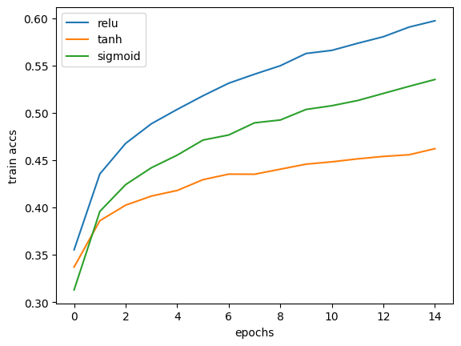

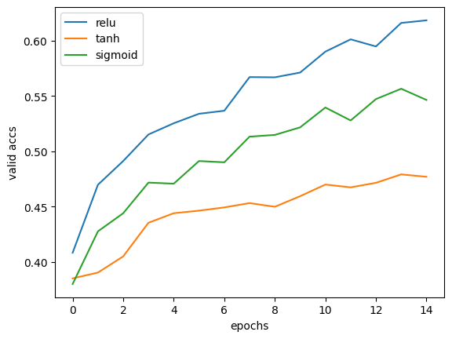

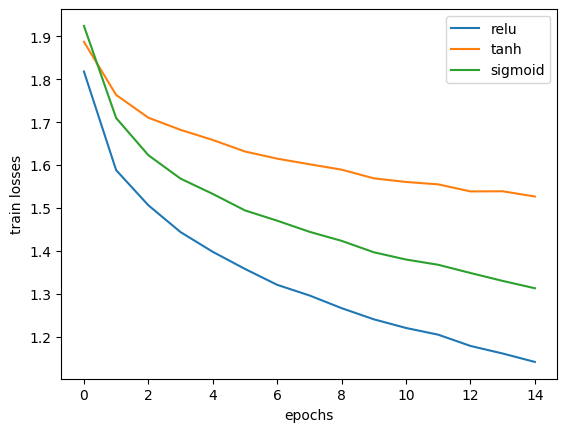

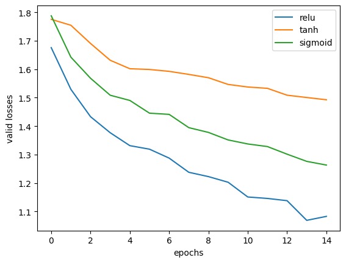

```python
from utils import generate_plots

list_of_dirs = ['exp/mlp_default', 'exp/mlp_tanh', 'exp/mlp_sigmoid']
names = ['relu', 'tanh', 'sigmoid']
save_path = 'figs/mlp_exps/'

generate_plots(list_of_dirs, names, save_path)
```

### Q3:

Hyperparameters other than learning rate:

- epochs: 15
- batch size: 128
- weight decay: 5e-4
- momentum: 0.9

| Learning rate | Test Accuracy |
| --- | --- |
| 1e-1 | 0.759592 |
| 1e-2 | 0.872033 |
| 1e-3 | 0.884394 |
| 1e-4 | 0.846518 |
| 1e-5 | 0.725870 |

1e-3 is the best learning rate. 1e-1 is too large. It could have overshot the minimum. 1e-5 is too small. It could have stayed at a local minimum.

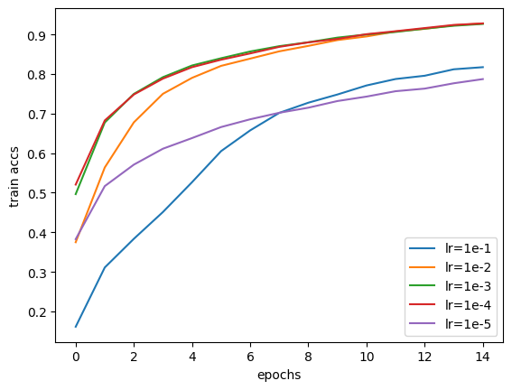

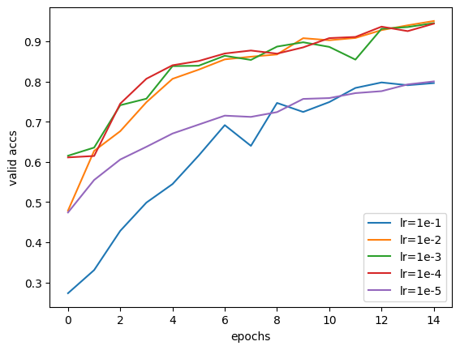

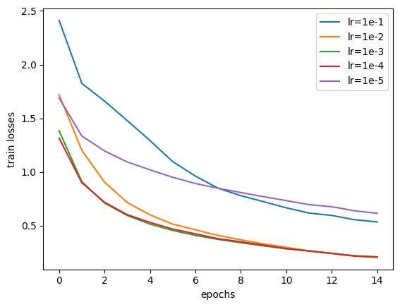

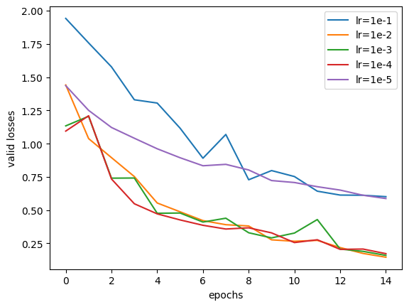

```python
from utils import generate_plots

list_of_dirs = ['exp/resnet1', 'exp/resnet2', 'exp/resnet3', 'exp/resnet4', 'exp/resnet5',]
names = ['lr=1e-1', 'lr=1e-2', 'lr=1e-3', 'lr=1e-4', 'lr=1e-5',]
save_path = 'figs/resnet18_exps'

generate_plots(list_of_dirs, names, save_path)
```

### Q4

Hyperparameters:

- lr: 1e-3
- epochs: 15
- batch size: 128
- weight decay: 5e-4
- momentum: 0.9

| patch size | number of model parameters | Average training time(s) | Test Accuracy |
| --- | --- | --- | --- |
| 2 | 2,376,458 | 43.053162 | 0.741 |
| 4 | 2,188,298 | 13.214978 | 0.756 |
| 8 | 2,175,818 | 8.241076 | 0.738 |
| 16 | 2,310,938 | 8.447986 | 0.642 |
| 32 | 2,897,678 | 9.384463 | 0.584 |

A patch size of 32 takes the most number of parameters and a patch size of 8 takes the least number of parameters. A patch size of 2 takes the longest time to train and a patch size of 8 takes the shortest time to train.

For patch sizes 16 and 32, the number of model parameters increases as the patch size increases. The average training time also increases as the patch size increases. As the patch size increases, the kernel size in projection also increases, which results in an increase in the number of weight parameters used to project a patch into embeded dimensions. Training time increases because multiplications needed to project a patch into embeded dimension increases.

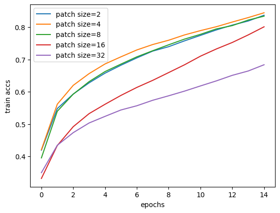

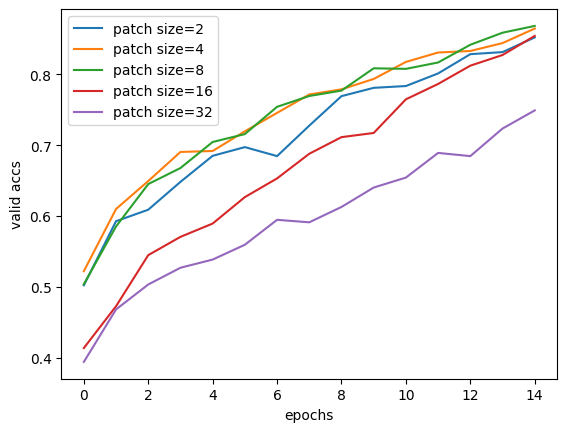

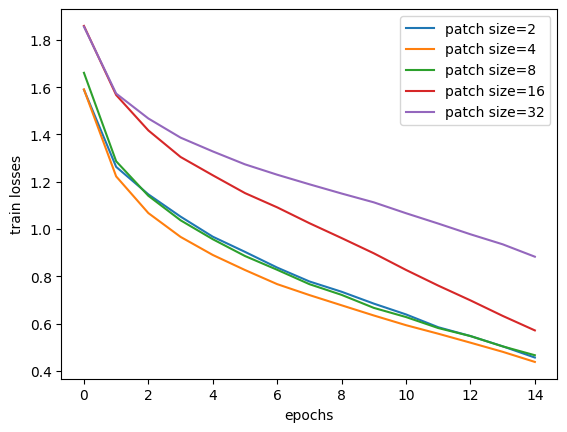

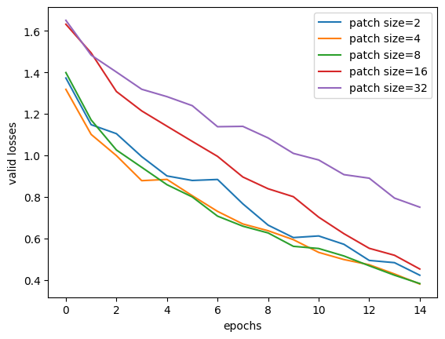

```python
from utils import generate_plots

list_of_dirs = ['exp/mlpmixer-2', 'exp/mlpmixer-4', 'exp/mlpmixer-8', 'exp/mlpmixer-16', 'exp/mlpmixer-32']
names = ['patch size=2', 'patch size=4', 'patch size=8', 'patch size=16', 'patch size=32']
save_path = 'figs/mlpmixer_exps'

generate_plots(list_of_dirs, names, save_path)
```

### Q5

Best hyper-parameters:

- lr = 1e-3
- momentum = 0.9
- weight decay = 3e-4
- epochs = 100
- batch_size = 128

[figure not shown]

### Q6

Best hyper-parameters for MLP-Mixer:

- lr = 1e-3
- momentum = 0.9
- weight decay = 4e-4
- epochs = 100
- batch_size = 128

Both CNN and MLP-mixer detect similar patterns of alternating opposing phases. CNN tend to focus on the local features such textures and frequncy changes, while token-mixing MLP aggregates spacial informations through dense matrix multiplications applied to every feature across all locations. It acts on the columns of patch x feature input tables and mixing features of every image patche. In other words, token-mixing MLPs allows global communications across all locations in the input image.

Here is a visualization of the first layer of the first block of token-MLP-mixer.

[figure not shown]